# Tp noté - Apprentissage supervisé 2A

### 3.3 Erreur de généralisation et erreur Out-Of-Bag

L’erreur OOB est une estimation de l’erreur de généralisation obtenue en utilisant chaque observation pour évaluer un modèle qui n’a pas été formé avec cette observation. C’est l’un des avantages des forêts aléatoires; elles fournissent une estimation interne de l’erreur de généralisation.

```r
predictions_rf <- predict(foret_aleatoire_final, data = test)$predictions
mse <- mean((predictions_rf - test$quality)^2)
print(paste("Erreur de généralisation (MSE): ", mse))
```

```
## [1] "Erreur de généralisation (MSE):  0.342247629276838"
```

```r
print(paste("Erreur Out-Of-Bag (OOB): ", foret_aleatoire_final$prediction.error))
```

```
## [1] "Erreur Out-Of-Bag (OOB):  0.351557738670018"
```

Nous constatons qu’il y a une faible différence entre l’erreur de généralisation et l’erreur Out-Of-Bag.

La proximité de ces deux erreurs suggère que notre modèle de forêt aléatoire est robuste et généralise bien aux nouvelles données, sans signe apparent de surajustement. Le fait que l’erreur de généralisation soit légèrement inférieure à l’erreur OOB indique également que notre modèle est bien ajusté.

En bref, notre modèle semble performant et fiable pour la prédiction de la qualité du vin.

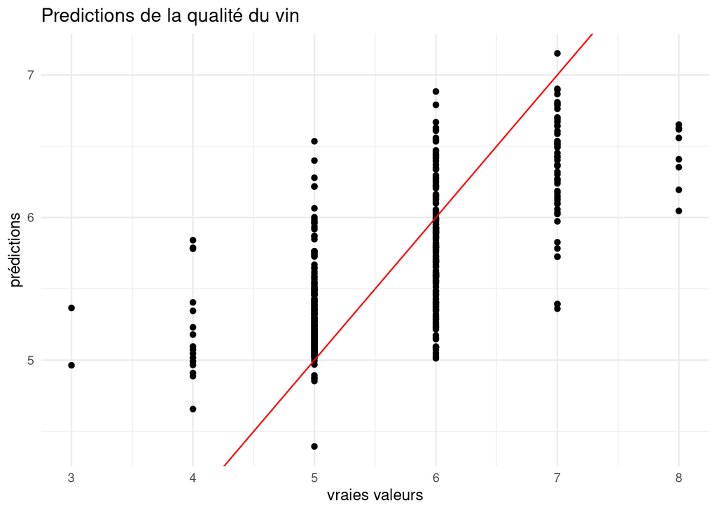

```r
data <- data.frame(TrueValues = test$quality, PredictedValues = predictions_rf)

ggplot(data, aes(x = TrueValues, y = PredictedValues)) +
  geom_point() +
  geom_abline(intercept = 0, slope = 1, color = "red") +
  theme_minimal() +
  labs(x = "vraies valeurs", y = "prédictions", title = "Predictions de la qualité du vin")
```

### 3.4 MDA importance (Mean decreasing accuracy)

L’idée principale de la MDA repose sur le fait que si une variable explicative n’est pas importante pour prédire la cible, qu’on la prenne en compte ou non dans la construction de la forêt ne devrait pas changer l’erreur de généralisation. Elle se calcule de la manière suivante :

$$MDA(X_j) = \frac{1}{n_{\text{test}}}
\sum_{i=1}^{n_{\text{test}}} l(y^*_i, \frac{1}{B} \sum_{b=1}^{B}
g^{(-j)}_b(x^*_i)) - l(y^*_i, \frac{1}{B} \sum_{b=1}^{B} g_b(x^*_i))$$
où $g^{-j}_b$ désigne la forêt aléatoire construite sans la j-ième variable explicative.

```r
set.seed(123)
B <- foret_aleatoire_final$num.trees
n_test <- nrow(test)

original_preds <- predict(foret_aleatoire_final, data = test)$predictions
original_loss <- mean((original_preds - test[["quality"]])^2) # MSE

feature_names <- names(test)
feature_names <- feature_names[feature_names != "quality"]
MDA_values <- numeric(length(feature_names))


for(j in seq_along(feature_names)) {
  temp_data <- train[, -j, with = FALSE]

  temp_forest <- ranger(quality ~., data = temp_data, num.trees = B)

  permuted_preds <- predict(temp_forest, data = test)$predictions
  permuted_loss <- mean((permuted_preds - test$quality)^2) # MSE après suppression de variable j

  MDA_values[feature_names[j]] <- (permuted_loss - original_loss)
}

sort(MDA_values[MDA_values != 0],decreasing = T)
```

```
##            sulphates              alcohol     volatile.acidity
##          0.030455227          0.020273317          0.008291053
## total.sulfur.dioxide              density        fixed.acidity
##          0.001383858          0.001140134         -0.001055960
##                   pH            chlorides       residual.sugar
##         -0.001080816         -0.002728286         -0.002733829
##          citric.acid  free.sulfur.dioxide
##         -0.004050135         -0.005262007
```

La sortie MDA montre l’importance des variables dans un modèle de forêt aléatoire. Les “sulphates” et “alcohol” ont les valeurs MDA les plus élevées, ce qui signifie qu’ils sont les plus importants pour la précision du modèle. Les variables comme “total.sulfur.dioxide” et “density” ont une importance moindre mais intéressante à savoir.

A l’inverse, des variables comme “fixed.acidity” et “citric.acid” etc. ont des valeurs MDA négatives, cela signifirait que les supprimer du modèle ferait baisser notre erreur de généralisation ce qui pourrait indiquer qu’elles ne sont pas très utiles dans ce modèle.

```r
sort(foret_aleatoire_final$variable.importance,decreasing = T)
```

```
##              alcohol            sulphates     volatile.acidity
##           0.23897721           0.14640084           0.10865621
##              density total.sulfur.dioxide          citric.acid
##           0.06882091           0.06813459           0.04634418
##                   pH        fixed.acidity            chlorides
##           0.04155543           0.04092841           0.03968719
##  free.sulfur.dioxide       residual.sugar
##           0.02945849           0.01623745
```

Dans la sortie d’importance de notre modèle constitué de toutes les variables explicatives, “Alcohol” prend la première place, suivi de “sulphates” et “volatile.acidity”.

Dans les deux cas, “alcohol”, “sulphates”, et “volatile.acidity” se démarquent comme les variables les plus influentes, mais leur ordre d’importance change. “Alcohol” est devenu plus dominant dans la sortie donné directement par le modèle.

# Bonus

```python
from umap import UMAP
import pandas as pd
import matplotlib.pyplot as plt
from sklearn.preprocessing import StandardScaler
from sklearn.metrics import silhouette_score
```

### 1. Validation croisée des paramètres UMAP

```python
df_train = pd.DataFrame(r.train)

# Séparer la variable d'intérêt et les features
X = df_train.drop(['quality'], axis=1)
y = df_train['quality']

# Normaliser les données
scaler = StandardScaler()
X_normalized = scaler.fit_transform(X)

#Grid de paramètres à tester
n_neighbors = [5, 10, 15, 20, 25]
min_dist = [0.1, 0.5, 1]

# Entraîner UMAP pour toutes les combinaisons de paramètres
best_score = -1
best_params = {}
for k in n_neighbors:
  for d in min_dist:
      umap = UMAP(n_neighbors=k, min_dist=d)
      projection = umap.fit_transform(X_normalized, y=y)

      # Calculer le score silhouette
      score = silhouette_score(projection, y)

      if score > best_score:
        best_score = score
        best_params = {"n_neighbors": k, "min_dist": d}

print("Meilleurs paramètres:", best_params)
```

```
## Meilleurs paramètres: {'n_neighbors': 25, 'min_dist': 0.1}
```

```python
print("Score silhouette:", best_score)
```

```
## Score silhouette: 0.45923865
```

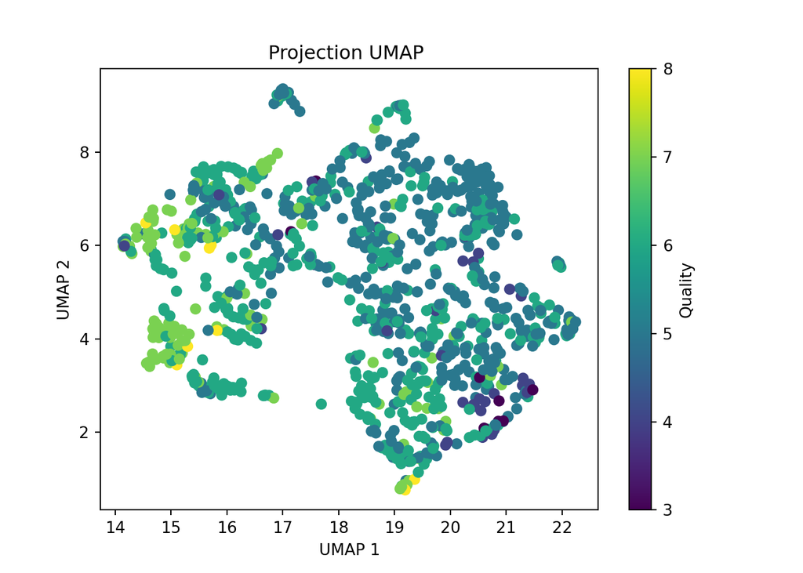

```python
# Réentraîner le meilleur modèle
umap_model = UMAP(n_neighbors=25, min_dist=0.1, n_components=2, target_metric='l1')
embedding = umap_model.fit_transform(X_normalized, y=y)

# Visualisation
plt.scatter(embedding[:, 0], embedding[:, 1], c=y, cmap='viridis')
plt.colorbar(label='Quality')
plt.title('Projection UMAP ')
plt.xlabel('UMAP 1')
plt.ylabel('UMAP 2')
plt.show()
```

### 2. Projection inverse et denormalisation

```python
import numpy as np

# Déterminer les limites de l'espace projeté
x_min, x_max = embedding[:, 0].min() - 1, embedding[:, 0].max() + 1
y_min, y_max = embedding[:, 1].min() - 1, embedding[:, 1].max() + 1

# Créer une grille 100x100
xx, yy = np.meshgrid(np.linspace(x_min, x_max, 100),
                     np.linspace(y_min, y_max, 100))

# Aplatir la grille pour l'inverse de la transformation
grid = np.c_[xx.ravel(), yy.ravel()]

# Calculer la projection inverse
inverse_transform = umap_model.inverse_transform(grid)

# Ne pas oublier de dé-normaliser les valeurs
inverse_transform_denorm = scaler.inverse_transform(inverse_transform)
```

### 3. Prédictions de la forêt aléatoire pour ces points

```r
inverse_transform_denorm <- as.data.frame(py$inverse_transform_denorm)
colnames(inverse_transform_denorm)<-colnames(train[,-12])
predictions_umap_denorm<- predict(foret_aleatoire_final, data = inverse_transform_denorm)$predictions
```

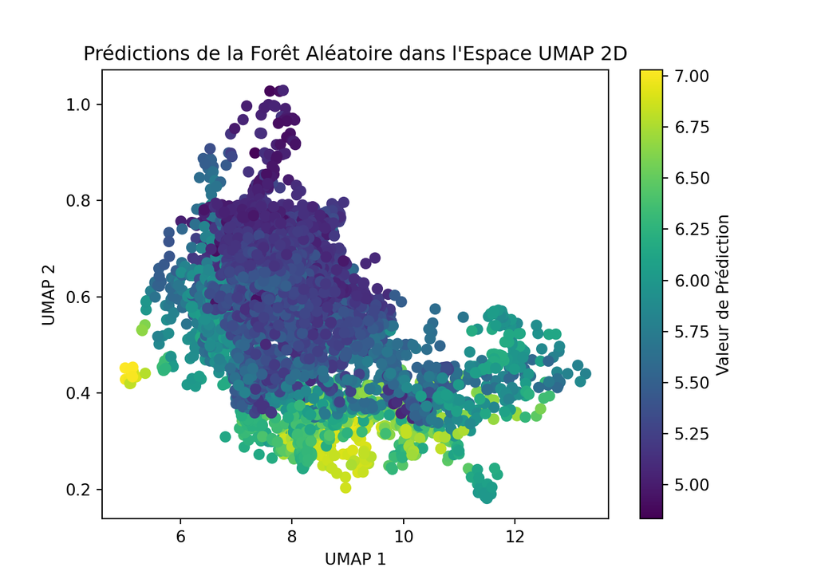

```python
# Transformer les prédictions en une matrice 100x100
predictions = np.array(r.predictions_umap_denorm).reshape(100, 100)

# Visualiser les prédictions dans l'espace UMAP
plt.scatter(inverse_transform_denorm[:, 0], inverse_transform_denorm[:, 1], c=predictions.ravel(), cmap='viridis')
plt.colorbar(label='Valeur de Prédiction')
plt.title('Prédictions de la Forêt Aléatoire dans l\'Espace UMAP 2D')
plt.xlabel('UMAP 1')
plt.ylabel('UMAP 2')
plt.show()
```